# PRONOSTICO DE LA DEMANDA

Limber López

22/3/2021

[figure not shown]

## UNIVERSIDAD CATOLICA BOLIVIANA “SAN PABLO”

## DIPLOMADO EN LOGISTICA INTEGRAL V.10

## MODULO: NUEVOS TOPICOS EN LOGISTICA II

## AUTOR: LIMBER R. LOPEZ Q.

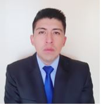

# 1. INTRODUCCION

[figure not shown]

Serigrafía Geele SRL, es una empresa productiva dedicada a la impresión serigráfica de envases plásticos, metálicos, vidrio y otros. Actualmente la empresa se encuentra en la zona de Villa Fátima en la ciudad de La Paz, el segmento de mercado está conformado por empresas nacionales de producción masiva (pinturas, shampoos, medicamentos, etc.). el proceso de producción es de forma semi industrial, con el uso de maquinaria semi automática en el proceso y una capacidad de producción de 50000 unidades impresas por mes.

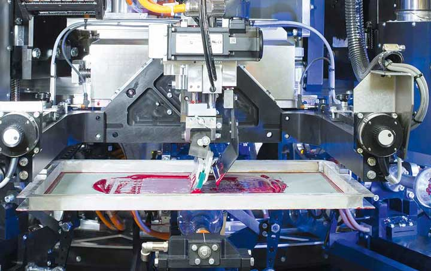

## Clientes

Monopol LTDA

[figure not shown]

Belmed LTDA

[figure not shown]

# 2. IDENTIFICACION DEL PROBLEMA

Debido a la coyuntura nacional que se atraviesa el país, la empresa Serigrafía Geele SRL ve prudente realizar un ponostico preciso de la demanda de productos impresos en su línea de “Balde 18L”, ya que en los ultimos periodos se generó demandas insatisfechas y sobrestock a causa del efecto látigo que atraviesan nuestros principales clientes, generando así variaciones de flujo económico.

## ANALISIS

Se tiene una base de datos donde se describe como variable endógena a la CANTIDAD DEMANDADA y variables exógenas: Cantidad de pintura en Kg, Envases disponibles, numero de personas, malla de impresión en metros y finalmente el área de impresión en metros cuadrados.

```r
library(readxl)
DEMANDA <- read_excel("C:/TRABAJO FINAL RSTUDIO/DEMANDA.xlsx",
    range = "A1:F31")
DEMANDA[c(1:31),]
```

```
## # A tibble: 31 x 6
##    Pintura Envase  MMOO Malla  Area `Cantidad Demandada`
##      <dbl>  <dbl> <dbl> <dbl> <dbl>                <dbl>
##  1    35    19500    10    18  4900                20000
##  2    28.5  15000     8    15  3500                15000
##  3    36.8  20000    10    20  4500                20000
##  4    33.8  20000    11    21  5300                21800
##  5    38.6  21000    11    20  5000                21400
##  6    33.8  17200    10    15  4000                16800
##  7    30.2  18000     9    20  4250                17800
##  8    27.6  20000    10    20  4700                19600
##  9    26.2  13500     8    15  3300                13700
## 10    37.9  20000    11    25  5200                21600
## # ... with 21 more rows
```

# 3 ANALISIS EXPLORATORIO DE DATOS

```r
summary(DEMANDA)
```

```
##     Pintura          Envase           MMOO            Malla
##  Min.   :18.90   Min.   :10000   Min.   : 8.000   Min.   :10.00
##  1st Qu.:28.56   1st Qu.:15000   1st Qu.: 9.000   1st Qu.:15.25
##  Median :32.09   Median :17600   Median :10.000   Median :20.00
##  Mean   :31.96   Mean   :17257   Mean   : 9.633   Mean   :18.80
##  3rd Qu.:36.31   3rd Qu.:20000   3rd Qu.:10.000   3rd Qu.:20.00
##  Max.   :40.80   Max.   :21000   Max.   :11.000   Max.   :25.00
##       Area      Cantidad Demandada
##  Min.   :3300   Min.   :13700
##  1st Qu.:4000   1st Qu.:16200
##  Median :4500   Median :18350
##  Mean   :4407   Mean   :18310
##  3rd Qu.:4800   3rd Qu.:20000
##  Max.   :5300   Max.   :21800
```

```r
DEMANDA1 <- read_excel("C:/TRABAJO FINAL RSTUDIO/DEMANDA.xlsx",
    range = "F1:G31")
DEMANDA1[c(1,2)]
```

```
## # A tibble: 30 x 2
##    `Cantidad Demandada` Periodo
##                   <dbl>   <dbl>
##  1                20000       1
##  2                15000       2
##  3                20000       3
##  4                21800       4
##  5                21400       5
##  6                16800       6
##  7                17800       7
##  8                19600       8
##  9                13700       9
## 10                21600      10
## # ... with 20 more rows
```

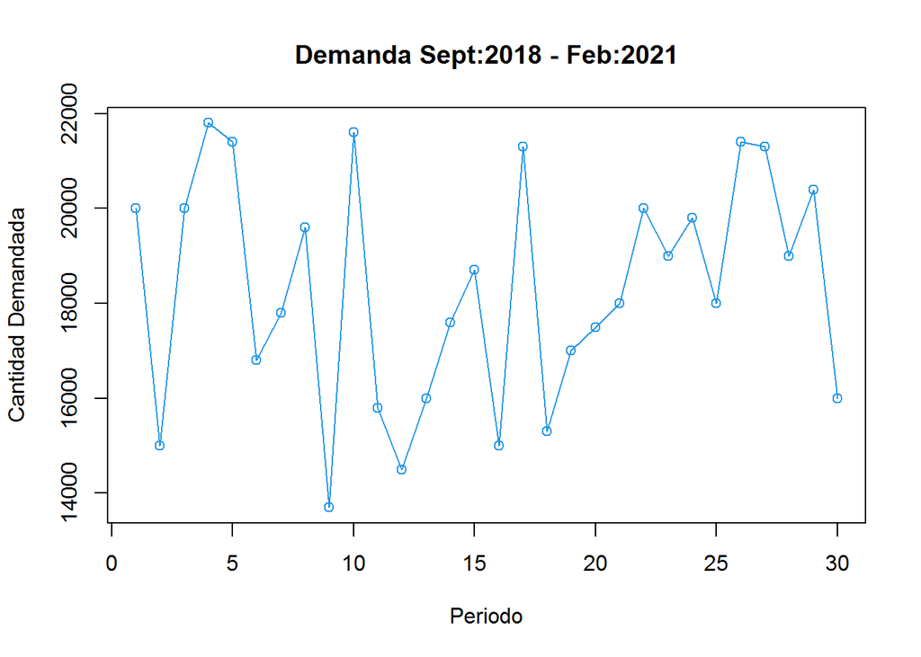

```r
with(DEMANDA1,plot(Periodo,`Cantidad Demandada`,col="52",type="o", main="Demanda Sept:2018 - Feb:2021"))
```

# 4 ANALISIS DE CORRELACION

## Cálculo del coeficiente de correlación

```r
round(cor(DEMANDA),2)
```

```
##                    Pintura Envase MMOO Malla Area Cantidad Demandada
## Pintura               1.00   0.85 0.45  0.20 0.46               0.46
## Envase                0.85   1.00 0.45  0.24 0.58               0.56
## MMOO                  0.45   0.45 1.00  0.55 0.86               0.91
## Malla                 0.20   0.24 0.55  1.00 0.67               0.66
## Area                  0.46   0.58 0.86  0.67 1.00               0.96
## Cantidad Demandada    0.46   0.56 0.91  0.66 0.96               1.00
```

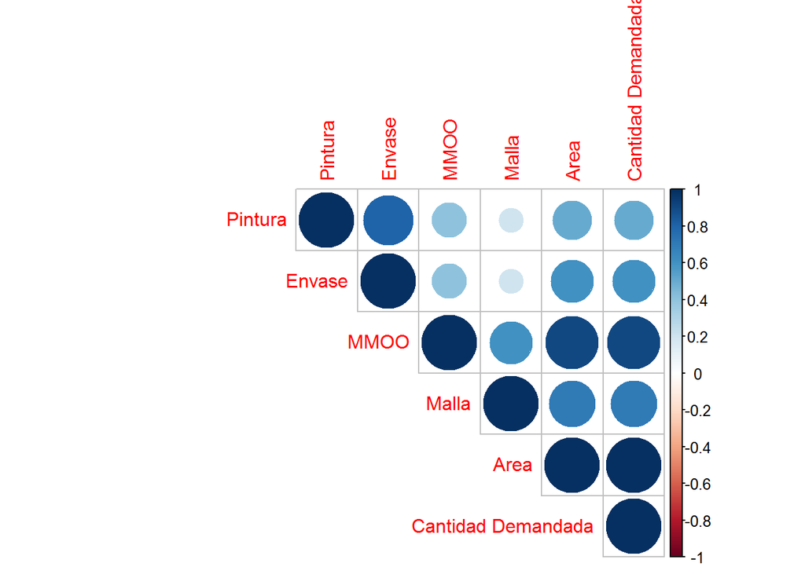

```r
library(corrplot)
library(psych)
correlacion <- round(cor(DEMANDA),1)
corrplot(correlacion, method = "circle", type = "upper")
```

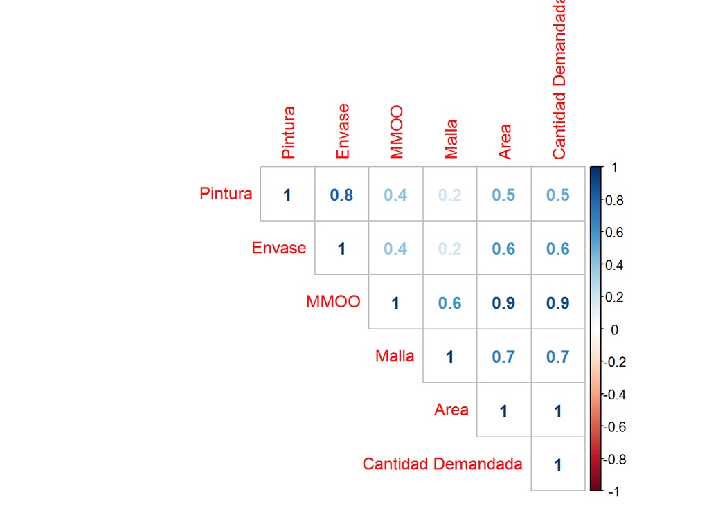

```r
corrplot(correlacion, method = "number", type = "upper")
```

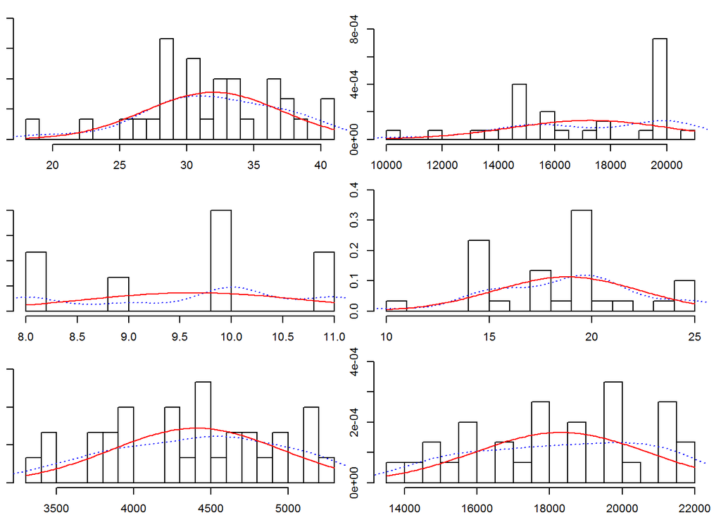

```r
multi.hist(x= DEMANDA, dcol = c("blue","red"), dlty = c("dotted", "solid"), main = "")
```

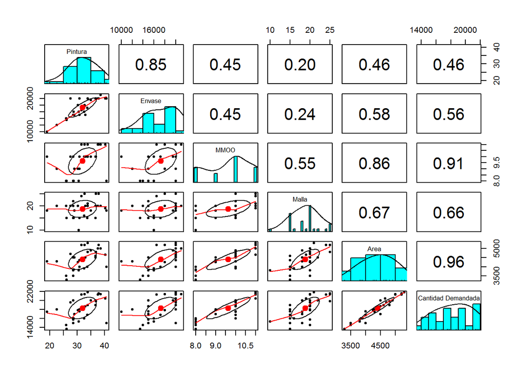

```r
library(psych)
pairs.panels(DEMANDA)
```

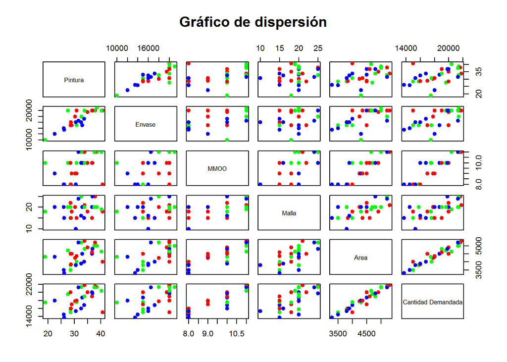

```r
pairs(DEMANDA, labels = colnames(DEMANDA), pch=21, bg= rainbow(3), col= rainbow(3), main= "Gráfico de dispersión")
```

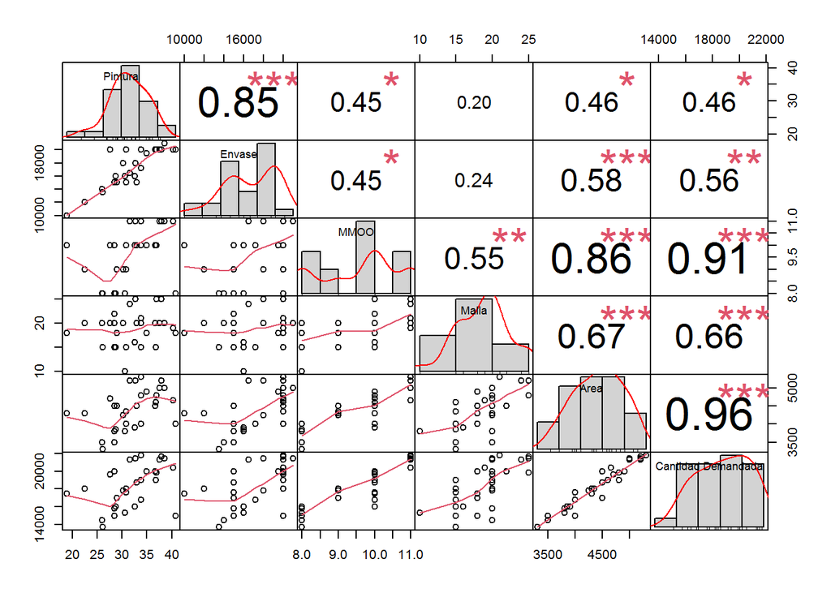

```r
chart.Correlation(DEMANDA, histogram = TRUE, method = "pearson")
```

# 5 GENERAR EL MODELO

#### Se pocede a realizar una regresión lineal multiple, donde la varibale dependiente sera “Cantidad Demandada”

```r
modelo <- lm(`Cantidad Demandada` ~ Pintura + Envase + MMOO + Malla + Area, data = DEMANDA)
summary(modelo)
```

```
##
## Call:
## lm(formula = `Cantidad Demandada` ~ Pintura + Envase + MMOO +
##     Malla + Area, data = DEMANDA)
##
## Residuals:
##      Min       1Q   Median       3Q      Max
## -1056.23  -278.73    68.03   357.18  1117.79
##
## Coefficients:
##               Estimate Std. Error t value Pr(>|t|)
## (Intercept) -1.564e+03  1.012e+03  -1.545 0.135320
## Pintura     -4.821e+01  4.344e+01  -1.110 0.278081
## Envase       1.214e-01  8.521e-02   1.424 0.167237
## MMOO         8.040e+02  2.104e+02   3.821 0.000827 ***
## Malla        4.975e+01  4.376e+01   1.137 0.266827
## Area         2.415e+00  5.269e-01   4.582 0.000120 ***
## ---
## Signif. codes:  0 '***' 0.001 '**' 0.01 '*' 0.05 '.' 0.1 ' ' 1
##
## Residual standard error: 590.1 on 24 degrees of freedom
## Multiple R-squared:   0.95,  Adjusted R-squared:  0.9396
## F-statistic: 91.26 on 5 and 24 DF,  p-value: 8.189e-15
```

## Coeficientes del modelo - Varianza estimada - Desviación Estándar

```r
coef(modelo)
```

```
##   (Intercept)       Pintura        Envase          MMOO         Malla
## -1564.2910066   -48.2071205     0.1213645   803.9624426    49.7530200
##          Area
##     2.4146106
```

```r
sigma(modelo)^2
```

```
## [1] 348180.1
```

```r
sigma(modelo)
```

```
## [1] 590.0679
```

## CONDICIONES PARA LA REGRESION MULTIPLE

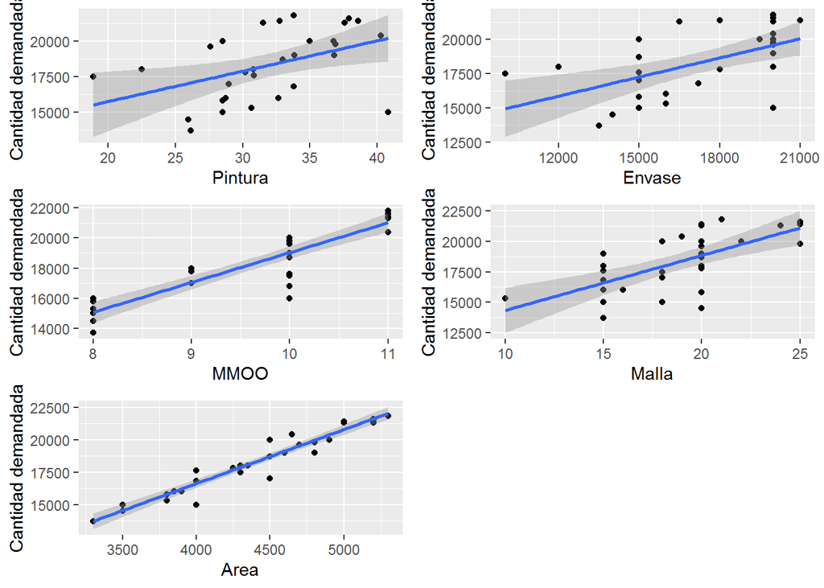

```r
library(ggplot2)
library(gridExtra)
A1 <- ggplot(DEMANDA, aes (x=Pintura, y=`Cantidad Demandada`)) + geom_point() + xlab("Pintura") + ylab("Cantidad demandada") + geom_smooth(method = lm)
A2 <- ggplot(DEMANDA, aes (x=Envase, y=`Cantidad Demandada`)) + geom_point() + xlab("Envase") + ylab("Cantidad demandada") + geom_smooth(method = lm)
A3 <- ggplot(DEMANDA, aes (x=MMOO, y=`Cantidad Demandada`)) + geom_point() + xlab("MMOO") + ylab("Cantidad demandada") + geom_smooth(method = lm)
A4 <- ggplot(DEMANDA, aes (x=Malla, y=`Cantidad Demandada`)) + geom_point() + xlab("Malla") + ylab("Cantidad demandada") + geom_smooth(method = lm)
A5 <- ggplot(DEMANDA, aes (x=Area, y=`Cantidad Demandada`)) + geom_point() + xlab("Area") + ylab("Cantidad demandada") + geom_smooth(method = lm)
grid.arrange(A1, A2, A3, A4, A5)
```

### Por lo tanto el modelo quedara como:

```r
confint(modelo, conf.level=0.95)
```

```
##                     2.5 %       97.5 %
## (Intercept) -3.653338e+03  524.7557590
## Pintura     -1.378580e+02   41.4437693
## Envase      -5.450168e-02    0.2972308
## MMOO         3.697021e+02 1238.2227731
## Malla       -4.057162e+01  140.0776568
## Area         1.327079e+00    3.5021422
```

# 6 Predicción del modélo

```r
nuevosperiodos <- data.frame(Pintura=c(40.0,32.8,35.65,40.70, 30.40), Envase=c(20000,22000,18000,21500,15000), MMOO=c(11,11,10,10,8), Malla=c(17,16,20,17,18), Area=c(4500,4800,3900,4200,3500))
nuevosperiodos
```

```
##   Pintura Envase MMOO Malla Area
## 1   40.00  20000   11    17 4500
## 2   32.80  22000   11    16 4800
## 3   35.65  18000   10    20 3900
## 4   40.70  21500   10    17 4200
## 5   30.40  15000    8    18 3500
```

### Pronóstico para 5 periodos futuros

```r
Pred <- predict(object = modelo, newdata = nuevosperiodos)
Pred
```

```
##        1        2        3        4        5
## 19489.85 20754.30 17353.35 18109.81 14569.07
```

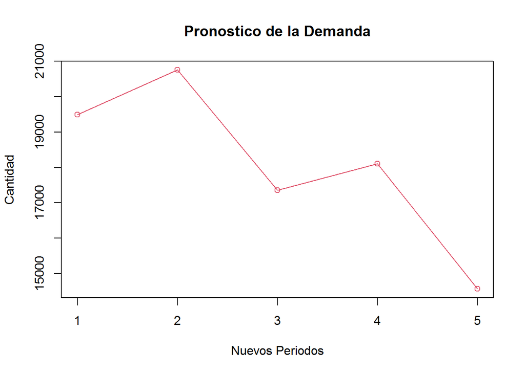

```r
plot(Pred, col="50", type="o", ylab = "Cantidad",xlab = "Nuevos Periodos", main= "Pronostico de la Demanda")
```

# 7 Referencias bibliográficas

### SERIGRAFIA GEELE SRL

http://www.serigrafiageele.com/

### Yuberth Anderson Saavedra Coneo

https://yuasaavedraco.github.io/Docs/Regresi%C3%B3n_lineal_m%C3%BAltiple_con_R.html

### Modelos de Regresión con R

https://fhernanb.github.io/libro_regresion/predict.html

### RPubs by RStudio

https://rpubs.com/Joaquin_AR/226291

### Manuel Sigüeñas Gonzales - Universidad Nacional Agraria La Molina

http://rstudio-pubs-static.s3.amazonaws.com/97848_cda6939060334a83b0e53b222b1e4b52.html